# Risk Factor Analysis

## Outcome Variable

**Outcome Variable:** haz

## Predictor Variables

**Intervention Variable:** mwtkg

**Adjustment Set:**

- arm
- W_mage
- meducyrs
- feducyrs
- single
- brthmon
- W_parity
- delta_W_mage
- delta_meducyrs
- delta_feducyrs
- delta_single
- delta_brthmon
- delta_W_parity

## Stratifying Variables

The analysis was stratified on these variable(s):

- agecat
- studyid
- country

## Data Summary

| agecat | studyid | country | mwtkg | n_cell | n | outcome_variable |
| --- | --- | --- | --- | --- | --- | --- |
| Birth | ki0047075b-MAL-ED | BANGLADESH | >=58 kg | 38 | 222 | haz |
| Birth | ki0047075b-MAL-ED | BANGLADESH | <52 kg | 143 | 222 | haz |
| Birth | ki0047075b-MAL-ED | BANGLADESH | [52-58) kg | 41 | 222 | haz |
| Birth | ki0047075b-MAL-ED | BRAZIL | >=58 kg | 34 | 64 | haz |
| Birth | ki0047075b-MAL-ED | BRAZIL | <52 kg | 15 | 64 | haz |
| Birth | ki0047075b-MAL-ED | BRAZIL | [52-58) kg | 15 | 64 | haz |
| Birth | ki0047075b-MAL-ED | INDIA | >=58 kg | 6 | 43 | haz |
| Birth | ki0047075b-MAL-ED | INDIA | <52 kg | 29 | 43 | haz |
| Birth | ki0047075b-MAL-ED | INDIA | [52-58) kg | 8 | 43 | haz |
| Birth | ki0047075b-MAL-ED | NEPAL | >=58 kg | 9 | 27 | haz |
| Birth | ki0047075b-MAL-ED | NEPAL | <52 kg | 8 | 27 | haz |
| Birth | ki0047075b-MAL-ED | NEPAL | [52-58) kg | 10 | 27 | haz |
| Birth | ki0047075b-MAL-ED | PERU | >=58 kg | 83 | 226 | haz |
| Birth | ki0047075b-MAL-ED | PERU | <52 kg | 84 | 226 | haz |
| Birth | ki0047075b-MAL-ED | PERU | [52-58) kg | 59 | 226 | haz |
| Birth | ki0047075b-MAL-ED | SOUTH AFRICA | >=58 kg | 69 | 101 | haz |
| Birth | ki0047075b-MAL-ED | SOUTH AFRICA | <52 kg | 10 | 101 | haz |
| Birth | ki0047075b-MAL-ED | SOUTH AFRICA | [52-58) kg | 22 | 101 | haz |
| Birth | ki0047075b-MAL-ED | TANZANIA, UNITED REPUBLIC OF | >=58 kg | 47 | 122 | haz |
| Birth | ki0047075b-MAL-ED | TANZANIA, UNITED REPUBLIC OF | <52 kg | 45 | 122 | haz |
| Birth | ki0047075b-MAL-ED | TANZANIA, UNITED REPUBLIC OF | [52-58) kg | 30 | 122 | haz |
| Birth | ki1000304b-SAS-CompFeed | INDIA | >=58 kg | 91 | 1236 | haz |
| Birth | ki1000304b-SAS-CompFeed | INDIA | <52 kg | 949 | 1236 | haz |
| Birth | ki1000304b-SAS-CompFeed | INDIA | [52-58) kg | 196 | 1236 | haz |
| Birth | ki1017093-NIH-Birth | BANGLADESH | >=58 kg | 80 | 608 | haz |
| Birth | ki1017093-NIH-Birth | BANGLADESH | <52 kg | 441 | 608 | haz |
| Birth | ki1017093-NIH-Birth | BANGLADESH | [52-58) kg | 87 | 608 | haz |
| Birth | ki1017093b-PROVIDE | BANGLADESH | >=58 kg | 91 | 517 | haz |
| Birth | ki1017093b-PROVIDE | BANGLADESH | <52 kg | 330 | 517 | haz |
| Birth | ki1017093b-PROVIDE | BANGLADESH | [52-58) kg | 96 | 517 | haz |

[output cut: 105 more lines]

The following strata were considered:

- agecat: 24 months, studyid: ki0047075b-MAL-ED, country: BANGLADESH
- agecat: 24 months, studyid: ki0047075b-MAL-ED, country: BRAZIL
- agecat: 24 months, studyid: ki0047075b-MAL-ED, country: INDIA
- agecat: 24 months, studyid: ki0047075b-MAL-ED, country: NEPAL
- agecat: 24 months, studyid: ki0047075b-MAL-ED, country: PERU
- agecat: 24 months, studyid: ki0047075b-MAL-ED, country: SOUTH AFRICA
- agecat: 24 months, studyid: ki0047075b-MAL-ED, country: TANZANIA, UNITED REPUBLIC OF
- agecat: 24 months, studyid: ki1017093-NIH-Birth, country: BANGLADESH
- agecat: 24 months, studyid: ki1017093b-PROVIDE, country: BANGLADESH
- agecat: 24 months, studyid: ki1017093c-NIH-Crypto, country: BANGLADESH
- agecat: 24 months, studyid: ki1066203-TanzaniaChild2, country: TANZANIA, UNITED REPUBLIC OF
- agecat: 24 months, studyid: ki1119695-PROBIT, country: BELARUS
- agecat: 24 months, studyid: ki1126311-ZVITAMBO, country: ZIMBABWE
- agecat: 24 months, studyid: ki1148112-LCNI-5, country: MALAWI
- agecat: 24 months, studyid: kiGH5241-JiVitA-3, country: BANGLADESH
- agecat: 6 months, studyid: ki0047075b-MAL-ED, country: BANGLADESH
- agecat: 6 months, studyid: ki0047075b-MAL-ED, country: BRAZIL
- agecat: 6 months, studyid: ki0047075b-MAL-ED, country: INDIA
- agecat: 6 months, studyid: ki0047075b-MAL-ED, country: NEPAL
- agecat: 6 months, studyid: ki0047075b-MAL-ED, country: PERU
- agecat: 6 months, studyid: ki0047075b-MAL-ED, country: SOUTH AFRICA
- agecat: 6 months, studyid: ki0047075b-MAL-ED, country: TANZANIA, UNITED REPUBLIC OF
- agecat: 6 months, studyid: ki1000304b-SAS-CompFeed, country: INDIA
- agecat: 6 months, studyid: ki1017093-NIH-Birth, country: BANGLADESH
- agecat: 6 months, studyid: ki1017093b-PROVIDE, country: BANGLADESH
- agecat: 6 months, studyid: ki1017093c-NIH-Crypto, country: BANGLADESH
- agecat: 6 months, studyid: ki1066203-TanzaniaChild2, country: TANZANIA, UNITED REPUBLIC OF
- agecat: 6 months, studyid: ki1119695-PROBIT, country: BELARUS
- agecat: 6 months, studyid: ki1126311-ZVITAMBO, country: ZIMBABWE
- agecat: 6 months, studyid: ki1148112-LCNI-5, country: MALAWI
- agecat: 6 months, studyid: kiGH5241-JiVitA-3, country: BANGLADESH
- agecat: Birth, studyid: ki0047075b-MAL-ED, country: BANGLADESH
- agecat: Birth, studyid: ki0047075b-MAL-ED, country: BRAZIL
- agecat: Birth, studyid: ki0047075b-MAL-ED, country: INDIA
- agecat: Birth, studyid: ki0047075b-MAL-ED, country: NEPAL
- agecat: Birth, studyid: ki0047075b-MAL-ED, country: PERU
- agecat: Birth, studyid: ki0047075b-MAL-ED, country: SOUTH AFRICA
- agecat: Birth, studyid: ki0047075b-MAL-ED, country: TANZANIA, UNITED REPUBLIC OF
- agecat: Birth, studyid: ki1000304b-SAS-CompFeed, country: INDIA
- agecat: Birth, studyid: ki1017093-NIH-Birth, country: BANGLADESH
- agecat: Birth, studyid: ki1017093b-PROVIDE, country: BANGLADESH
- agecat: Birth, studyid: ki1017093c-NIH-Crypto, country: BANGLADESH
- agecat: Birth, studyid: ki1119695-PROBIT, country: BELARUS
- agecat: Birth, studyid: ki1126311-ZVITAMBO, country: ZIMBABWE
- agecat: Birth, studyid: kiGH5241-JiVitA-3, country: BANGLADESH

### Dropped Strata

Some strata were dropped due to rare outcomes:

- agecat: 24 months, studyid: ki1066203-TanzaniaChild2, country: TANZANIA, UNITED REPUBLIC OF

## Methods Detail

We’re interested in the causal parameters $E[Y_a]$ for all values of $a \in \mathcal{A}$. These parameters represent the mean outcome if, possibly contrary to fact, we intervened to set all units to have $A=a$. Under the randomization and positivity assumptions, these are identified by the statistical parameters $\psi_a=E_W[E_{Y|A,W}(Y|A=a,W)]$. In addition, we’re interested in the mean of $Y$, $E[Y]$ under no intervention (the observed mean). We will estimate these parameters by using SuperLearner to fit the relevant likelihood factors – $E_{Y|A,W}(Y|A=a,W)$ and $p(A=a|W)$, and then updating our likelihood fit using a joint TMLE.

For unadjusted analyses ($W=\{\}$), initial likelihoods were estimated using Lrnr_glm to estimate the simple $E(Y|A)$ and Lrnr_mean to estimate $p(A)$. For adjusted analyses, a small library containing Lrnr_glmnet, Lrnr_xgboost, and Lrnr_mean was used.

Having estimated these parameters, we will then use the delta method to estimate relative risks and attributable risks relative to a prespecified baseline level of $A$.

# Results Detail

## Results Plots

[figure not shown]

[figure not shown]

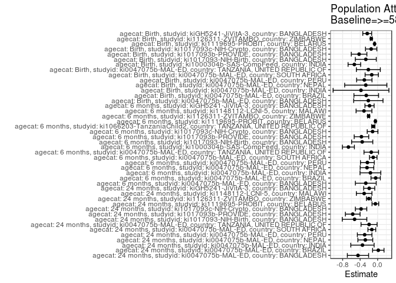

## Results Table

### Parameter: TSM

| agecat | studyid | country | intervention_level | baseline_level | estimate | ci_lower | ci_upper |
| --- | --- | --- | --- | --- | --- | --- | --- |
| Birth | ki0047075b-MAL-ED | BANGLADESH | >=58 kg | NA | -0.8654428 | -1.2293642 | -0.5015213 |
| Birth | ki0047075b-MAL-ED | BANGLADESH | <52 kg | NA | -1.2189493 | -1.3895300 | -1.0483687 |
| Birth | ki0047075b-MAL-ED | BANGLADESH | [52-58) kg | NA | -0.7336822 | -1.0520797 | -0.4152847 |
| Birth | ki0047075b-MAL-ED | BRAZIL | >=58 kg | NA | -0.4284655 | -0.8032441 | -0.0536869 |
| Birth | ki0047075b-MAL-ED | BRAZIL | <52 kg | NA | -1.2021504 | -1.8963669 | -0.5079340 |
| Birth | ki0047075b-MAL-ED | BRAZIL | [52-58) kg | NA | -0.9478832 | -1.5402927 | -0.3554736 |
| Birth | ki0047075b-MAL-ED | INDIA | >=58 kg | NA | -0.8500000 | -1.5073907 | -0.1926093 |
| Birth | ki0047075b-MAL-ED | INDIA | <52 kg | NA | -1.2131034 | -1.5635569 | -0.8626500 |
| Birth | ki0047075b-MAL-ED | INDIA | [52-58) kg | NA | -1.5775000 | -2.4667124 | -0.6882876 |
| Birth | ki0047075b-MAL-ED | NEPAL | >=58 kg | NA | -0.5822222 | -1.1447657 | -0.0196787 |
| Birth | ki0047075b-MAL-ED | NEPAL | <52 kg | NA | -1.6712500 | -2.1476338 | -1.1948662 |
| Birth | ki0047075b-MAL-ED | NEPAL | [52-58) kg | NA | -0.4430000 | -0.9133974 | 0.0273974 |
| Birth | ki0047075b-MAL-ED | PERU | >=58 kg | NA | -0.6005757 | -0.8220562 | -0.3790952 |
| Birth | ki0047075b-MAL-ED | PERU | <52 kg | NA | -1.1713432 | -1.3567024 | -0.9859839 |
| Birth | ki0047075b-MAL-ED | PERU | [52-58) kg | NA | -0.8679374 | -1.0721260 | -0.6637489 |
| Birth | ki0047075b-MAL-ED | SOUTH AFRICA | >=58 kg | NA | -0.4362248 | -0.6640179 | -0.2084316 |
| Birth | ki0047075b-MAL-ED | SOUTH AFRICA | <52 kg | NA | -1.2830516 | -1.8575560 | -0.7085472 |
| Birth | ki0047075b-MAL-ED | SOUTH AFRICA | [52-58) kg | NA | -0.7489711 | -1.2677092 | -0.2302329 |
| Birth | ki0047075b-MAL-ED | TANZANIA, UNITED REPUBLIC OF | >=58 kg | NA | -0.9243377 | -1.2658097 | -0.5828658 |
| Birth | ki0047075b-MAL-ED | TANZANIA, UNITED REPUBLIC OF | <52 kg | NA | -1.4357159 | -1.7974666 | -1.0739652 |
| Birth | ki0047075b-MAL-ED | TANZANIA, UNITED REPUBLIC OF | [52-58) kg | NA | -0.9732300 | -1.3588137 | -0.5876462 |
| Birth | ki1000304b-SAS-CompFeed | INDIA | >=58 kg | NA | -0.8898972 | -1.0530403 | -0.7267541 |
| Birth | ki1000304b-SAS-CompFeed | INDIA | <52 kg | NA | -1.5281036 | -1.6181723 | -1.4380348 |
| Birth | ki1000304b-SAS-CompFeed | INDIA | [52-58) kg | NA | -1.1572862 | -1.3208097 | -0.9937627 |
| Birth | ki1017093-NIH-Birth | BANGLADESH | >=58 kg | NA | -0.6606054 | -0.9152733 | -0.4059375 |
| Birth | ki1017093-NIH-Birth | BANGLADESH | <52 kg | NA | -1.0226542 | -1.1262012 | -0.9191072 |
| Birth | ki1017093-NIH-Birth | BANGLADESH | [52-58) kg | NA | -0.7661895 | -1.0264905 | -0.5058885 |
| Birth | ki1017093b-PROVIDE | BANGLADESH | >=58 kg | NA | -0.4684100 | -0.6615075 | -0.2753124 |
| Birth | ki1017093b-PROVIDE | BANGLADESH | <52 kg | NA | -1.0257457 | -1.1104969 | -0.9409944 |
| Birth | ki1017093b-PROVIDE | BANGLADESH | [52-58) kg | NA | -0.7641207 | -0.9742815 | -0.5539599 |

[output cut: 102 more lines]

### Parameter: E(Y)

| agecat | studyid | country | intervention_level | baseline_level | estimate | ci_lower | ci_upper |
| --- | --- | --- | --- | --- | --- | --- | --- |
| Birth | ki0047075b-MAL-ED | BANGLADESH | NA | NA | -1.0778829 | -1.2122580 | -0.9435077 |
| Birth | ki0047075b-MAL-ED | BRAZIL | NA | NA | -0.6884375 | -0.9678371 | -0.4090379 |
| Birth | ki0047075b-MAL-ED | INDIA | NA | NA | -1.2302326 | -1.5393614 | -0.9211037 |
| Birth | ki0047075b-MAL-ED | NEPAL | NA | NA | -0.8533333 | -1.2104864 | -0.4961803 |
| Birth | ki0047075b-MAL-ED | PERU | NA | NA | -0.9051327 | -1.0238686 | -0.7863969 |
| Birth | ki0047075b-MAL-ED | SOUTH AFRICA | NA | NA | -0.5707921 | -0.7685593 | -0.3730248 |
| Birth | ki0047075b-MAL-ED | TANZANIA, UNITED REPUBLIC OF | NA | NA | -1.1364754 | -1.3478823 | -0.9250686 |
| Birth | ki1000304b-SAS-CompFeed | INDIA | NA | NA | -1.4220793 | -1.5007856 | -1.3433730 |
| Birth | ki1017093-NIH-Birth | BANGLADESH | NA | NA | -0.9310197 | -1.0197391 | -0.8423003 |
| Birth | ki1017093b-PROVIDE | BANGLADESH | NA | NA | -0.8925145 | -0.9687201 | -0.8163089 |
| Birth | ki1017093c-NIH-Crypto | BANGLADESH | NA | NA | -0.9089163 | -0.9806324 | -0.8372002 |
| Birth | ki1119695-PROBIT | BELARUS | NA | NA | 1.3272020 | 1.1683762 | 1.4860279 |
| Birth | ki1126311-ZVITAMBO | ZIMBABWE | NA | NA | -0.4966839 | -0.5196015 | -0.4737663 |
| Birth | kiGH5241-JiVitA-3 | BANGLADESH | NA | NA | -1.5896135 | -1.6088760 | -1.5703510 |
| 6 months | ki0047075b-MAL-ED | BANGLADESH | NA | NA | -1.2049931 | -1.3222136 | -1.0877726 |
| 6 months | ki0047075b-MAL-ED | BRAZIL | NA | NA | 0.0497516 | -0.0948051 | 0.1943083 |
| 6 months | ki0047075b-MAL-ED | INDIA | NA | NA | -1.2059574 | -1.3243030 | -1.0876119 |
| 6 months | ki0047075b-MAL-ED | NEPAL | NA | NA | -0.5615819 | -0.6741832 | -0.4489807 |
| 6 months | ki0047075b-MAL-ED | PERU | NA | NA | -1.3241023 | -1.4325083 | -1.2156964 |
| 6 months | ki0047075b-MAL-ED | SOUTH AFRICA | NA | NA | -1.0727443 | -1.2024880 | -0.9430006 |
| 6 months | ki0047075b-MAL-ED | TANZANIA, UNITED REPUBLIC OF | NA | NA | -1.3687449 | -1.4907629 | -1.2467270 |
| 6 months | ki1000304b-SAS-CompFeed | INDIA | NA | NA | -1.4003907 | -1.4819787 | -1.3188027 |
| 6 months | ki1017093-NIH-Birth | BANGLADESH | NA | NA | -1.4073821 | -1.4960598 | -1.3187043 |
| 6 months | ki1017093b-PROVIDE | BANGLADESH | NA | NA | -1.0895301 | -1.1639589 | -1.0151013 |
| 6 months | ki1017093c-NIH-Crypto | BANGLADESH | NA | NA | -1.1986783 | -1.2700937 | -1.1272630 |
| 6 months | ki1066203-TanzaniaChild2 | TANZANIA, UNITED REPUBLIC OF | NA | NA | -0.5424765 | -0.5918460 | -0.4931071 |
| 6 months | ki1119695-PROBIT | BELARUS | NA | NA | 0.1143882 | 0.0212298 | 0.2075466 |
| 6 months | ki1126311-ZVITAMBO | ZIMBABWE | NA | NA | -0.8785195 | -0.9045379 | -0.8525011 |
| 6 months | ki1148112-LCNI-5 | MALAWI | NA | NA | -1.6584707 | -1.7281551 | -1.5887863 |
| 6 months | kiGH5241-JiVitA-3 | BANGLADESH | NA | NA | -1.3134847 | -1.3366230 | -1.2903464 |
| 24 months | ki0047075b-MAL-ED | BANGLADESH | NA | NA | -1.9783962 | -2.1050210 | -1.8517715 |
| 24 months | ki0047075b-MAL-ED | BRAZIL | NA | NA | 0.0059127 | -0.1637934 | 0.1756188 |
| 24 months | ki0047075b-MAL-ED | INDIA | NA | NA | -1.8844690 | -2.0097879 | -1.7591502 |
| 24 months | ki0047075b-MAL-ED | NEPAL | NA | NA | -1.3075877 | -1.4270718 | -1.1881037 |
| 24 months | ki0047075b-MAL-ED | PERU | NA | NA | -1.7524710 | -1.8736426 | -1.6312994 |
| 24 months | ki0047075b-MAL-ED | SOUTH AFRICA | NA | NA | -1.6432229 | -1.7795844 | -1.5068615 |
| 24 months | ki0047075b-MAL-ED | TANZANIA, UNITED REPUBLIC OF | NA | NA | -2.6455607 | -2.7807256 | -2.5103959 |
| 24 months | ki1017093-NIH-Birth | BANGLADESH | NA | NA | -2.2190579 | -2.3217459 | -2.1163699 |
| 24 months | ki1017093b-PROVIDE | BANGLADESH | NA | NA | -1.6002600 | -1.6836163 | -1.5169036 |
| 24 months | ki1017093c-NIH-Crypto | BANGLADESH | NA | NA | -1.4412646 | -1.5249156 | -1.3576135 |
| 24 months | ki1119695-PROBIT | BELARUS | NA | NA | -0.1312742 | -0.4286264 | 0.1660780 |
| 24 months | ki1126311-ZVITAMBO | ZIMBABWE | NA | NA | -1.6070497 | -1.6645093 | -1.5495902 |
| 24 months | ki1148112-LCNI-5 | MALAWI | NA | NA | -1.8854671 | -1.9666281 | -1.8043062 |
| 24 months | kiGH5241-JiVitA-3 | BANGLADESH | NA | NA | -2.0134183 | -2.0410747 | -1.9857620 |

### Parameter: ATE

| agecat | studyid | country | intervention_level | baseline_level | estimate | ci_lower | ci_upper |
| --- | --- | --- | --- | --- | --- | --- | --- |
| Birth | ki0047075b-MAL-ED | BANGLADESH | >=58 kg | >=58 kg | 0.0000000 | 0.0000000 | 0.0000000 |
| Birth | ki0047075b-MAL-ED | BANGLADESH | <52 kg | >=58 kg | -0.3535066 | -0.7564144 | 0.0494012 |
| Birth | ki0047075b-MAL-ED | BANGLADESH | [52-58) kg | >=58 kg | 0.1317606 | -0.3517096 | 0.6152308 |
| Birth | ki0047075b-MAL-ED | BRAZIL | >=58 kg | >=58 kg | 0.0000000 | 0.0000000 | 0.0000000 |
| Birth | ki0047075b-MAL-ED | BRAZIL | <52 kg | >=58 kg | -0.7736849 | -1.5746795 | 0.0273097 |
| Birth | ki0047075b-MAL-ED | BRAZIL | [52-58) kg | >=58 kg | -0.5194176 | -1.2312435 | 0.1924083 |
| Birth | ki0047075b-MAL-ED | INDIA | >=58 kg | >=58 kg | 0.0000000 | 0.0000000 | 0.0000000 |
| Birth | ki0047075b-MAL-ED | INDIA | <52 kg | >=58 kg | -0.3631034 | -1.1080734 | 0.3818665 |
| Birth | ki0047075b-MAL-ED | INDIA | [52-58) kg | >=58 kg | -0.7275000 | -1.8333306 | 0.3783306 |
| Birth | ki0047075b-MAL-ED | NEPAL | >=58 kg | >=58 kg | 0.0000000 | 0.0000000 | 0.0000000 |
| Birth | ki0047075b-MAL-ED | NEPAL | <52 kg | >=58 kg | -1.0890278 | -1.8261822 | -0.3518733 |
| Birth | ki0047075b-MAL-ED | NEPAL | [52-58) kg | >=58 kg | 0.1392222 | -0.5940778 | 0.8725223 |
| Birth | ki0047075b-MAL-ED | PERU | >=58 kg | >=58 kg | 0.0000000 | 0.0000000 | 0.0000000 |
| Birth | ki0047075b-MAL-ED | PERU | <52 kg | >=58 kg | -0.5707675 | -0.8614731 | -0.2800619 |
| Birth | ki0047075b-MAL-ED | PERU | [52-58) kg | >=58 kg | -0.2673618 | -0.5708487 | 0.0361252 |
| Birth | ki0047075b-MAL-ED | SOUTH AFRICA | >=58 kg | >=58 kg | 0.0000000 | 0.0000000 | 0.0000000 |
| Birth | ki0047075b-MAL-ED | SOUTH AFRICA | <52 kg | >=58 kg | -0.8468268 | -1.4664725 | -0.2271812 |
| Birth | ki0047075b-MAL-ED | SOUTH AFRICA | [52-58) kg | >=58 kg | -0.3127463 | -0.8808812 | 0.2553886 |
| Birth | ki0047075b-MAL-ED | TANZANIA, UNITED REPUBLIC OF | >=58 kg | >=58 kg | 0.0000000 | 0.0000000 | 0.0000000 |
| Birth | ki0047075b-MAL-ED | TANZANIA, UNITED REPUBLIC OF | <52 kg | >=58 kg | -0.5113782 | -1.0108295 | -0.0119268 |
| Birth | ki0047075b-MAL-ED | TANZANIA, UNITED REPUBLIC OF | [52-58) kg | >=58 kg | -0.0488922 | -0.5659105 | 0.4681260 |
| Birth | ki1000304b-SAS-CompFeed | INDIA | >=58 kg | >=58 kg | 0.0000000 | 0.0000000 | 0.0000000 |
| Birth | ki1000304b-SAS-CompFeed | INDIA | <52 kg | >=58 kg | -0.6382064 | -0.7974505 | -0.4789622 |
| Birth | ki1000304b-SAS-CompFeed | INDIA | [52-58) kg | >=58 kg | -0.2673890 | -0.4831308 | -0.0516472 |
| Birth | ki1017093-NIH-Birth | BANGLADESH | >=58 kg | >=58 kg | 0.0000000 | 0.0000000 | 0.0000000 |
| Birth | ki1017093-NIH-Birth | BANGLADESH | <52 kg | >=58 kg | -0.3620489 | -0.6372819 | -0.0868158 |
| Birth | ki1017093-NIH-Birth | BANGLADESH | [52-58) kg | >=58 kg | -0.1055841 | -0.4714690 | 0.2603007 |
| Birth | ki1017093b-PROVIDE | BANGLADESH | >=58 kg | >=58 kg | 0.0000000 | 0.0000000 | 0.0000000 |
| Birth | ki1017093b-PROVIDE | BANGLADESH | <52 kg | >=58 kg | -0.5573357 | -0.7674164 | -0.3472550 |
| Birth | ki1017093b-PROVIDE | BANGLADESH | [52-58) kg | >=58 kg | -0.2957107 | -0.5794538 | -0.0119676 |

[output cut: 102 more lines]

### Parameter: PAR

| agecat | studyid | country | intervention_level | baseline_level | estimate | ci_lower | ci_upper |
| --- | --- | --- | --- | --- | --- | --- | --- |
| Birth | ki0047075b-MAL-ED | BANGLADESH | >=58 kg | NA | -0.2124401 | -0.5478670 | 0.1229868 |
| Birth | ki0047075b-MAL-ED | BRAZIL | >=58 kg | NA | -0.2599720 | -0.5419978 | 0.0220538 |
| Birth | ki0047075b-MAL-ED | INDIA | >=58 kg | NA | -0.3802326 | -1.0182919 | 0.2578268 |
| Birth | ki0047075b-MAL-ED | NEPAL | >=58 kg | NA | -0.2711111 | -0.7538568 | 0.2116346 |
| Birth | ki0047075b-MAL-ED | PERU | >=58 kg | NA | -0.3045571 | -0.4806098 | -0.1285044 |
| Birth | ki0047075b-MAL-ED | SOUTH AFRICA | >=58 kg | NA | -0.1345673 | -0.2866075 | 0.0174729 |
| Birth | ki0047075b-MAL-ED | TANZANIA, UNITED REPUBLIC OF | >=58 kg | NA | -0.2121377 | -0.4861867 | 0.0619114 |
| Birth | ki1000304b-SAS-CompFeed | INDIA | >=58 kg | NA | -0.5321821 | -0.6762389 | -0.3881253 |
| Birth | ki1017093-NIH-Birth | BANGLADESH | >=58 kg | NA | -0.2704144 | -0.5102304 | -0.0305983 |
| Birth | ki1017093b-PROVIDE | BANGLADESH | >=58 kg | NA | -0.4241045 | -0.6025726 | -0.2456364 |
| Birth | ki1017093c-NIH-Crypto | BANGLADESH | >=58 kg | NA | -0.1478271 | -0.2779994 | -0.0176549 |
| Birth | ki1119695-PROBIT | BELARUS | >=58 kg | NA | -0.0697528 | -0.0807955 | -0.0587102 |
| Birth | ki1126311-ZVITAMBO | ZIMBABWE | >=58 kg | NA | -0.1450784 | -0.1674533 | -0.1227035 |
| Birth | kiGH5241-JiVitA-3 | BANGLADESH | >=58 kg | NA | -0.2380131 | -0.3396546 | -0.1363716 |
| 6 months | ki0047075b-MAL-ED | BANGLADESH | >=58 kg | NA | -0.2707319 | -0.5090944 | -0.0323694 |
| 6 months | ki0047075b-MAL-ED | BRAZIL | >=58 kg | NA | -0.0449287 | -0.1519094 | 0.0620520 |
| 6 months | ki0047075b-MAL-ED | INDIA | >=58 kg | NA | -0.1650148 | -0.4026004 | 0.0725708 |
| 6 months | ki0047075b-MAL-ED | NEPAL | >=58 kg | NA | -0.2432141 | -0.3987366 | -0.0876917 |
| 6 months | ki0047075b-MAL-ED | PERU | >=58 kg | NA | -0.2345400 | -0.3923977 | -0.0766824 |
| 6 months | ki0047075b-MAL-ED | SOUTH AFRICA | >=58 kg | NA | -0.0998594 | -0.1853625 | -0.0143563 |
| 6 months | ki0047075b-MAL-ED | TANZANIA, UNITED REPUBLIC OF | >=58 kg | NA | -0.1455210 | -0.3120428 | 0.0210007 |
| 6 months | ki1000304b-SAS-CompFeed | INDIA | >=58 kg | NA | -0.6683274 | -0.8053865 | -0.5312682 |
| 6 months | ki1017093-NIH-Birth | BANGLADESH | >=58 kg | NA | -0.3526231 | -0.5946407 | -0.1106054 |
| 6 months | ki1017093b-PROVIDE | BANGLADESH | >=58 kg | NA | -0.3699086 | -0.5360012 | -0.2038160 |
| 6 months | ki1017093c-NIH-Crypto | BANGLADESH | >=58 kg | NA | -0.1156430 | -0.2383471 | 0.0070610 |
| 6 months | ki1066203-TanzaniaChild2 | TANZANIA, UNITED REPUBLIC OF | >=58 kg | NA | -0.1000941 | -0.1377673 | -0.0624208 |
| 6 months | ki1119695-PROBIT | BELARUS | >=58 kg | NA | -0.0513816 | -0.0665652 | -0.0361980 |
| 6 months | ki1126311-ZVITAMBO | ZIMBABWE | >=58 kg | NA | -0.2064593 | -0.2315384 | -0.1813801 |
| 6 months | ki1148112-LCNI-5 | MALAWI | >=58 kg | NA | -0.3118972 | -0.4928833 | -0.1309111 |
| 6 months | kiGH5241-JiVitA-3 | BANGLADESH | >=58 kg | NA | -0.1851696 | -0.2899001 | -0.0804391 |
| 24 months | ki0047075b-MAL-ED | BANGLADESH | >=58 kg | NA | -0.4494322 | -0.6928319 | -0.2060325 |
| 24 months | ki0047075b-MAL-ED | BRAZIL | >=58 kg | NA | 0.0153233 | -0.1153143 | 0.1459610 |
| 24 months | ki0047075b-MAL-ED | INDIA | >=58 kg | NA | -0.3469687 | -0.6137464 | -0.0801909 |
| 24 months | ki0047075b-MAL-ED | NEPAL | >=58 kg | NA | -0.2816897 | -0.4515431 | -0.1118363 |
| 24 months | ki0047075b-MAL-ED | PERU | >=58 kg | NA | -0.2969156 | -0.4637267 | -0.1301046 |
| 24 months | ki0047075b-MAL-ED | SOUTH AFRICA | >=58 kg | NA | -0.1327733 | -0.2220509 | -0.0434957 |
| 24 months | ki0047075b-MAL-ED | TANZANIA, UNITED REPUBLIC OF | >=58 kg | NA | -0.1954575 | -0.3793016 | -0.0116134 |
| 24 months | ki1017093-NIH-Birth | BANGLADESH | >=58 kg | NA | -0.5277365 | -0.8083840 | -0.2470891 |
| 24 months | ki1017093b-PROVIDE | BANGLADESH | >=58 kg | NA | -0.5693635 | -0.7373585 | -0.4013686 |
| 24 months | ki1017093c-NIH-Crypto | BANGLADESH | >=58 kg | NA | -0.3784929 | -0.5091683 | -0.2478176 |
| 24 months | ki1119695-PROBIT | BELARUS | >=58 kg | NA | -0.0515625 | -0.1281259 | 0.0250008 |
| 24 months | ki1126311-ZVITAMBO | ZIMBABWE | >=58 kg | NA | -0.2005634 | -0.2558646 | -0.1452623 |
| 24 months | ki1148112-LCNI-5 | MALAWI | >=58 kg | NA | -0.3081682 | -0.4864669 | -0.1298695 |
| 24 months | kiGH5241-JiVitA-3 | BANGLADESH | >=58 kg | NA | -0.1928471 | -0.3198113 | -0.0658828 |